# Ford GoBike Data exploration

## by Dina Adel Shalabi

## Investigation Overview

> In this report I will try to come up with some insights for the sales entity for Ford GoBike dataset!

## Dataset Overview

This data set includes information about individual rides made in a bike-sharing system covering the greater San Francisco Bay area.  
Our data contains 174952 records for 16 columns (17 after I added member_age column).

The features that we will use during our investigation:  
duration_sec  
user_type  
member_gender  
member_age

### What is the structure of your dataset?

> Our data contains 174952 records for 16 columns (17 after I added member_age column).

### What is/are the main feature(s) of interest in your dataset?

> When are most trips taken in terms of time of day, day of the week, or month of the year, by customers or subscribers?  
> How long does the average trip take?  
> Does the above depend on if a user is a subscriber or customer?  
> Bikers ages and gender analysis for sales point of views..

### What features in the dataset do you think will help support your investigation into your feature(s) of interest?

> **The features that we will use during our investigation:**  
> duration_sec  
> user_type  
> member_gender  
> member_age

## Univariate Exploration

>In this section, investigate distributions of individual variables. If you see unusual points or outliers, take a deeper look to clean things up and prepare yourself to look at relationships between variables.

*Members Gender*

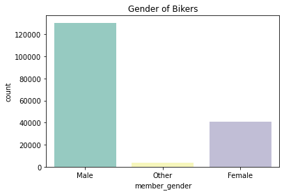

So as we see, the major number of members are males, followed by females and others

*User Types*

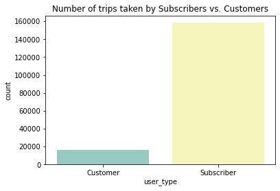

*User Ages*

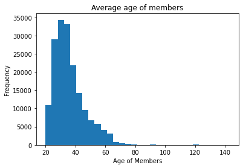

### Now let's inspect the trip's start and end times

We should start looking at the peak days where bikes are used...

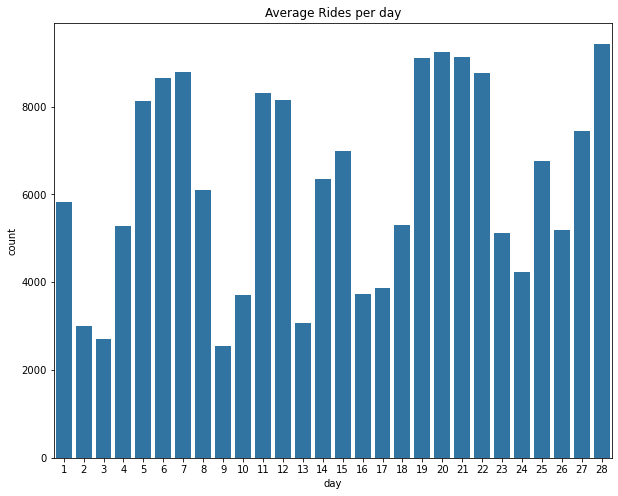

Now let's have a look at the duration/minute

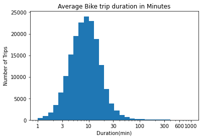

As seen from our plot, the average trip duration is 10 minutes

### Discuss the distribution(s) of your variable(s) of interest. Were there any unusual points? Did you need to perform any transformations?

> First, the data was recorded in the month of February. We saw that there are some records that have end time in March but we removed them.  
> We also did some algorthimic transformations to help improve skewed plots.

## Bivariate Exploration

>In this section, investigate relationships between pairs of variables in your data. Make sure the variables that you cover here have been introduced in some fashion in the previous section (univariate exploration).

### *The Relationship between User type and Duration of trip in minutes*

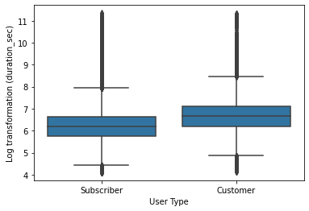

Here we've done some log transformation on the duration in seconds, so we could see the relationship between both variables.  
**As we can see that mean duration per second of a customer's trip is greater than that of a subscriber...interesting!**

### *Let's investigate the relationship between the a Member's age and the Duration of his trip in seconds*

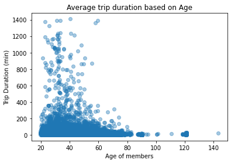

### *Now let's see the relationship between the Member's Gender and the duration of his/her trip*

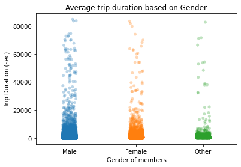

## Multivariate Exploration

Create plots of three or more variables to investigate your data even further. Make sure that your investigations are justified, and follow from your work in the previous sections.

### *Let's investigate the relation between the members gender, their types and the duration of their trips*

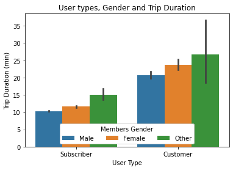

As we see from our graph that customers(all genders) tend to have longer trips than subscribers.